# Practice Code: Day 2

Author

Constantin Manuel Bosancianu

Published

July 30, 2019

# 1 Introduction

We start as yesterday, by loading a few needed packages, and by defining a few custom functions we use below.

```r
library(pacman)
p_load(tidyverse, broom, ggeffects, texreg, arm, broom.mixed,
       knitr, kableExtra, magrittr, ggthemes)
```

We also define here a few helpful functions we will rely on in this code file.

```r
fun_stderr <- function(x, na.rm = TRUE) {
    if (na.rm) x <- na.omit(x)
    sqrt(var(x) / length(x))
}
```

# 2 Reading data

Read the same ISSP data set we used yesterday; we keep only the variables we will use today, and do listwise deletion of missing data from the outset.

```r
df_issp <- readRDS("../02-data/01-ISSP.rds")

df_issp %<>%
    dplyr::select(cnt, year, country, poleff, female,
                  age10, educ, urban, incquart, ti_cpi) %>%
    na.omit() %>%
    mutate(female = as.factor(female),
           urban = as.factor(urban),
           incquart = as.factor(incquart))
```

# 3 Complete pooling vs. no pooling

Complete pooling designates the model that we fit yesterday - it uses the entire sample to estimate the relationship between predictors and outcome, without any thought given to group membership.

```r
model1.lm <- lm(poleff ~ 1 + age10 + female + educ + urban +
                    incquart,
                data = df_issp)

summary(model1.lm)
```

```
Call:
lm(formula = poleff ~ 1 + age10 + female + educ + urban + incquart,
    data = df_issp)

Residuals:
    Min      1Q  Median      3Q     Max
-2.4885 -0.5166 -0.0156  0.5074  6.2614

Coefficients:
              Estimate Std. Error t value Pr(>|t|)
(Intercept)  2.1664803  0.0194776 111.229  < 2e-16 ***
age10        0.0346543  0.0022664  15.291  < 2e-16 ***
female1     -0.1433696  0.0076376 -18.772  < 2e-16 ***
educ         0.0434269  0.0009875  43.976  < 2e-16 ***
urban1       0.0873506  0.0077367  11.290  < 2e-16 ***
incquart2    0.0710817  0.0108540   6.549 5.87e-11 ***
incquart3    0.1337318  0.0110176  12.138  < 2e-16 ***
incquart4    0.2537740  0.0113588  22.342  < 2e-16 ***
---
Signif. codes:  0 '***' 0.001 '**' 0.01 '*' 0.05 '.' 0.1 ' ' 1

Residual standard error: 0.7372 on 37620 degrees of freedom
Multiple R-squared:  0.09817,   Adjusted R-squared:  0.098
F-statistic:   585 on 7 and 37620 DF,  p-value: < 2.2e-16
```

Based on this model, all we can say is that the effect of education, or gender, on political efficacy is the same for every respondent, irrespective of which country they come from. Its virtue is that it uses information from the entire sample to estimate the relationship, which results in very small standard errors.

The alternative is what we tried yesterday: running each model separately for each group. The challenge with this approach is that the only information used in the estimation originates with the group itself.

Take as an example the case of Poland. Suppose that instead of 1,892 cases, it had 378 observations (about 20% of the original sample).

```r
set.seed(395722)
df_pl <- df_issp %>%
    sample_n(378)

df_issp_temp <- rbind(subset(df_issp, !(df_issp$cnt == "PL")),
                      df_pl)
rm(df_pl)
```

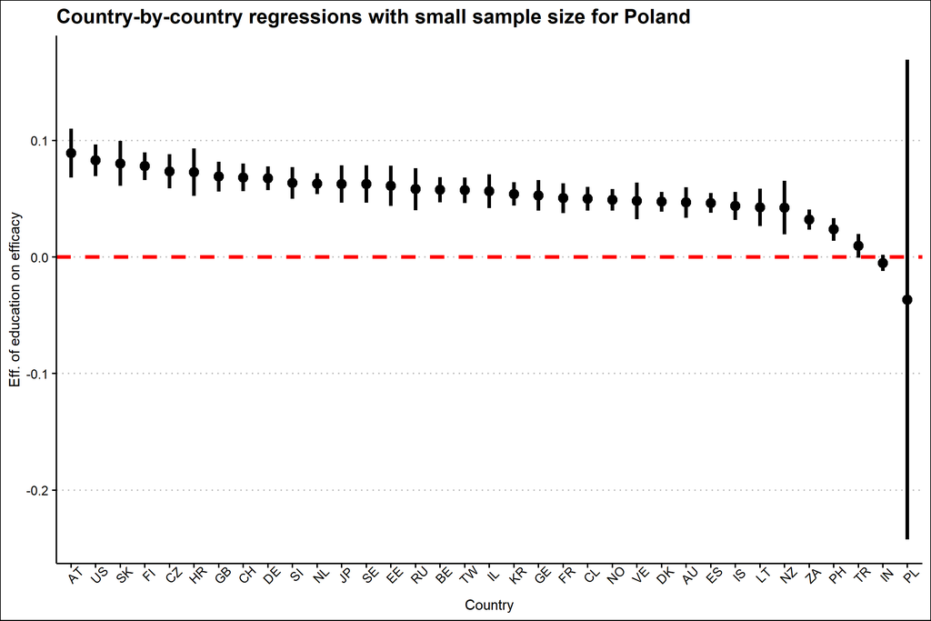

```r
df_issp_temp %>%
    nest(data = -cnt) %>%
    mutate(mod1 = map(data,
                      ~lm(poleff ~ age10 + female + educ + urban,
                          data = .)),
           results = map(mod1, tidy)) %>%
    unnest(results) %>%
    filter(term == "educ") %>%
    ggplot(aes(x = reorder(cnt, -estimate),
               y = estimate)) +
    geom_point(size = 3) +
    geom_errorbar(aes(ymin = estimate - 1.96 * std.error,
                      ymax = estimate + 1.96 * std.error),
                  width = 0, linewidth = 1.25) +
    labs(x = "Country",
         y = "Eff. of education on efficacy",
         title = "Country-by-country regressions with small sample size for Poland") + # nolint
    geom_hline(yintercept = 0,
               linewidth = 1.25,
               color = "red",
               linetype = "dashed") +
    theme_clean() +
    theme(axis.text.x = element_text(angle = 45))
```

# 4 Multilevel model: random intercepts

We will use the `lmer()` function from the `lme4` package for these models. I have loaded the `arm` package because this automatically calls the `lme4` package, but also makes available some additional post-estimation function designed by Gelman and Hill.

## 4.1 First model

```r
mlm.1 <- lmer(formula = poleff ~ 1 + age10 + female + educ + urban +
                    incquart + (1 | cnt),
              data = df_issp_temp,
              REML = TRUE,
              control = lmerControl(optimizer = "bobyqa"))
```

A few comments on the syntax above:

- As long as you start with the formula syntax, there’s no need to write `formula =` every time
- The model syntax is very similar to regression. on LHS of the `~` is the outcome, while on RHS of the `~` come the predictors (and intercept for the model). These would be the “fixed-effects” in the model.After these, inside the brackets, come the random effects
- Add as many random effects as your specification requires before the `|`. In this case, I only have a random intercept, which is why I wrote only “1” before the `|`. On the RHS of the `|` comes the grouping factor(s), which in my case is `cnt`
- `REML =` specifies the type of estimation that is carried out. We will cover this in one of the next sessions. Even if you don’t specify it, the model will run, as REML estimation is the default
- `control =` allows you to finely control the estimation process, including modifying the default tolerance value, or increase the number of maximum iterations that the model is allowed to run for. The default for `lmer()` is the `nloptwrap` optimizer, which for my data issues a convergence warning. Though the warning does not affect the estimates, it is still annoying to see. This is why I used an alternative optimizer - the results between the two are identical up to the 5th decimal point

```r
summary(mlm.1)
```

```
Linear mixed model fit by REML ['lmerMod']
Formula: poleff ~ 1 + age10 + female + educ + urban + incquart + (1 |      cnt)
   Data: df_issp_temp
Control: lmerControl(optimizer = "bobyqa")

REML criterion at convergence: 75909.5

Scaled residuals:
    Min      1Q  Median      3Q     Max
-4.0537 -0.6755 -0.0091  0.6763  8.7510

Random effects:
 Groups   Name        Variance Std.Dev.
 cnt      (Intercept) 0.09363  0.3060
 Residual             0.47591  0.6899
Number of obs: 36114, groups:  cnt, 35

Fixed effects:
             Estimate Std. Error t value
(Intercept)  2.165027   0.055797  38.802
age10        0.038296   0.002285  16.756
female1     -0.120168   0.007324 -16.408
educ         0.040853   0.001053  38.796
urban1       0.053035   0.007939   6.680
incquart2    0.074655   0.010370   7.199
incquart3    0.146469   0.010543  13.893
incquart4    0.275187   0.010913  25.216

Correlation of Fixed Effects:
          (Intr) age10  femal1 educ   urban1 incqr2 incqr3
age10     -0.266
female1   -0.082  0.023
educ      -0.252  0.241  0.001
urban1    -0.031  0.008 -0.010 -0.132
incquart2 -0.082  0.024  0.035 -0.089  0.005
incquart3 -0.079  0.082  0.057 -0.166  0.002  0.513
incquart4 -0.053  0.084  0.078 -0.274 -0.040  0.509  0.537
```

Take a while to look a bit at the result output - looks fairly similar to that from the `lm()` function in how it is structured, except that it has a few additional fields: “Random effects” and “Correlation of Fixed Effects”.[^1]

<sup>1</sup> Why no stars for the output? Because that’s how the original creator of the package wanted it, for very good reasons: https://stat.ethz.ch/pipermail/r-help/2006-May/094765.html.

## 4.2 Quantities of interest

You can use a few functions to obtain the fixed effects and random effects from the model.

```r
fixef(mlm.1) # The fixed effects
```

```
(Intercept)       age10     female1        educ      urban1   incquart2
 2.16502673  0.03829644 -0.12016817  0.04085305  0.05303522  0.07465478
  incquart3   incquart4
 0.14646890  0.27518656
```

```r
se.fixef(mlm.1) # SEs for the fixed effects
```

```
(Intercept)       age10     female1        educ      urban1   incquart2
0.055796612 0.002285468 0.007323853 0.001053026 0.007939097 0.010369556
  incquart3   incquart4
0.010542725 0.010913149
```

In our case, only a random intercept was specified.

```r
ranef(mlm.1) # The random effects (deviations) in the model
```

```
$cnt
   (Intercept)
AT -0.06844226
AU  0.20184581
BE -0.06156283
CH  0.37233399
CL  0.17262298
CZ -0.33443402
DE  0.17870769
DK  0.27340296
EE -0.15988027
ES -0.11184014
FI  0.04397398
FR  0.43342476
GB  0.08096315
GE -0.21784471
HR -0.32028243
IL -0.31729922
IN -0.04605182
IS  0.39384011
JP  0.12556006
KR -0.27681358
LT -0.42890740
NL  0.17497009
NO  0.45075772
NZ  0.22810221
PH  0.12062522
PL -0.76061822
RU -0.16868387
SE  0.25305191
SI -0.53342086
SK -0.34004365
TR  0.33978971
TW -0.06331020
US  0.01420176
VE  0.52051182
ZA -0.16925046

with conditional variances for "cnt"
```

```r
# The SEs for random effects (function from the "arm" package).
se.ranef(mlm.1)
```

```
$cnt
   (Intercept)
AT  0.02523930
AU  0.02400214
BE  0.01669684
CH  0.02173848
CL  0.02284255
CZ  0.02038653
DE  0.01782353
DK  0.01671154
EE  0.02999162
ES  0.01998060
FI  0.02205839
FR  0.02659056
GB  0.01889440
GE  0.01991389
HR  0.02679032
IL  0.02570813
IN  0.02113830
IS  0.02490810
JP  0.01993883
KR  0.01861716
LT  0.02515526
NL  0.01876118
NO  0.01957431
NZ  0.02896933
PH  0.01989732
PL  0.14680298
RU  0.02462090
SE  0.02460524
SI  0.02849589
SK  0.02185818
TR  0.02087536
TW  0.01881693
US  0.02029809
VE  0.02246398
ZA  0.01461163
```

You can also ask for the confidence intervals, if you prefer them.

```r
confint(mlm.1,
        level = 0.95)
```

```
                  2.5 %      97.5 %
.sig01       0.23917680  0.39261506
.sigma       0.68479229  0.69485900
(Intercept)  2.05429353  2.27506312
age10        0.03381758  0.04277575
female1     -0.13452731 -0.10581984
educ         0.03878983  0.04291728
urban1       0.03748518  0.06860491
incquart2    0.05433071  0.09497583
incquart3    0.12580462  0.16712853
incquart4    0.25379265  0.29656878
```

Alternatively, you can use a function in the `broom.mixed` package that extracts the same quantities (for the first 20 countries in the sample).

```r
tidy(mlm.1) %>%
    kable(caption = "Tidied output for multilevel model",
          digits = 3) %>%
    kable_styling(full_width = FALSE)
```

Tidied output for multilevel model

| effect | group | term | estimate | std.error | statistic |
| --- | --- | --- | --- | --- | --- |
| fixed | NA | (Intercept) | 2.165 | 0.056 | 38.802 |
| fixed | NA | age10 | 0.038 | 0.002 | 16.756 |
| fixed | NA | female1 | -0.120 | 0.007 | -16.408 |
| fixed | NA | educ | 0.041 | 0.001 | 38.796 |
| fixed | NA | urban1 | 0.053 | 0.008 | 6.680 |
| fixed | NA | incquart2 | 0.075 | 0.010 | 7.199 |
| fixed | NA | incquart3 | 0.146 | 0.011 | 13.893 |
| fixed | NA | incquart4 | 0.275 | 0.011 | 25.216 |
| ran_pars | cnt | sd__(Intercept) | 0.306 | NA | NA |
| ran_pars | Residual | sd__Observation | 0.690 | NA | NA |

```r
augment(ranef(mlm.1),
        ci.level = 0.95) %>%
    slice(1:20) %>%
    kable(caption = "Augmented output for multilevel model",
          digits = 3) %>%
    kable_styling(full_width = FALSE)
```

Augmented output for multilevel model

| grp | variable | level | estimate | qq | std.error | lb | ub |
| --- | --- | --- | --- | --- | --- | --- | --- |
| cnt | (Intercept) | PL | -0.761 | -0.291 | 0.025 | -0.810 | -0.711 |
| cnt | (Intercept) | SI | -0.533 | 0.608 | 0.024 | -0.580 | -0.486 |
| cnt | (Intercept) | LT | -0.429 | -0.144 | 0.017 | -0.462 | -0.396 |
| cnt | (Intercept) | SK | -0.340 | 1.133 | 0.022 | -0.383 | -0.297 |
| cnt | (Intercept) | CZ | -0.334 | 0.366 | 0.023 | -0.379 | -0.290 |
| cnt | (Intercept) | HR | -0.320 | -1.133 | 0.020 | -0.360 | -0.280 |
| cnt | (Intercept) | IL | -0.317 | 0.524 | 0.018 | -0.352 | -0.282 |
| cnt | (Intercept) | KR | -0.277 | 0.894 | 0.017 | -0.310 | -0.244 |
| cnt | (Intercept) | GE | -0.218 | -0.444 | 0.030 | -0.277 | -0.159 |
| cnt | (Intercept) | ZA | -0.169 | -0.366 | 0.020 | -0.208 | -0.130 |
| cnt | (Intercept) | RU | -0.169 | 0.072 | 0.022 | -0.212 | -0.125 |
| cnt | (Intercept) | EE | -0.160 | 1.465 | 0.027 | -0.212 | -0.108 |
| cnt | (Intercept) | ES | -0.112 | 0.144 | 0.019 | -0.149 | -0.075 |
| cnt | (Intercept) | AT | -0.068 | -0.697 | 0.020 | -0.107 | -0.029 |
| cnt | (Intercept) | TW | -0.063 | -1.006 | 0.027 | -0.116 | -0.011 |
| cnt | (Intercept) | BE | -0.062 | -0.894 | 0.026 | -0.112 | -0.011 |
| cnt | (Intercept) | IN | -0.046 | -0.072 | 0.021 | -0.087 | -0.005 |
| cnt | (Intercept) | US | 0.014 | 1.282 | 0.025 | -0.035 | 0.063 |
| cnt | (Intercept) | FI | 0.044 | 0.291 | 0.020 | 0.005 | 0.083 |
| cnt | (Intercept) | GB | 0.081 | -0.792 | 0.019 | 0.044 | 0.117 |

## 4.3 Comparison: no-pooling and multilevel

How do the intercepts from the no-pooling model compare to those from the multilevel one?

I use here the variant of “no-pooling” that Gelman and Hill describe: a model with country indicators. The “-1” tells **R** to estimate values for all countries, rather than use one of the countries as reference group.

```r
model.np <- lm(poleff ~ as.factor(cnt) - 1 + age10 + female + educ +
                    urban + incquart,
               data = df_issp_temp)

df_nopool <- model.np %>%
    tidy() %>%
    dplyr::select(c(term, estimate, std.error)) %>%
    filter(str_detect(term, "cnt")) %>%
    mutate(term = str_sub(term, start = -2),
           model = "nopool") %>%
    rename(cnt = term)
rm(model.np)
```

We next generate the random effects from the multilevel model.[^2]

<sup>2</sup> In the code below we have to add the value of the overall intercept, since the random effects are deviations from this overall intercept.

```r
df_mlm <- augment(ranef(mlm.1),
                  ci.level = 0.95)

df_mlm %<>%
    dplyr::select(c(level, estimate, std.error)) %>%
    rename(cnt = level) %>%
    mutate(model = "mlm",
           estimate = estimate + fixef(mlm.1)["(Intercept)"])
```

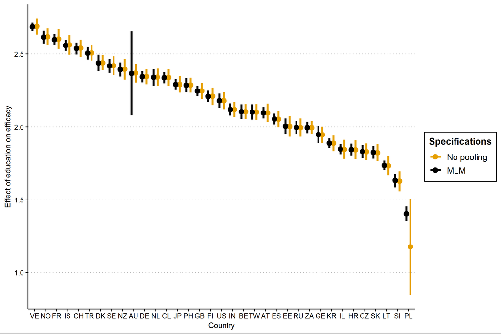

```r
df_plot <- rbind(df_nopool, df_mlm)
rm(df_nopool, df_mlm)

df_plot %>%
    mutate(cnt = factor(cnt, levels = cnt[model == "mlm"])) %>%
    ggplot(aes(x = reorder(cnt, -estimate),
               y = estimate),
           color = model,
           group = model) +
    geom_point(size = 3,
               position = position_dodge(width = 0.75),
               aes(color = model)) +
    labs(x = "Country",
         y = "Effect of education on efficacy") +
    theme_clean() +
    geom_errorbar(aes(ymin = estimate - 1.96 * std.error,
                      ymax = estimate + 1.96 * std.error,
                      color = model),
                  linewidth = 1.25,
                  position = position_dodge(width = 0.75),
                  width = 0) +
    scale_color_colorblind(name = "Specifications",
                           breaks = c("nopool","mlm"),
                           labels = c("No pooling", "MLM"))
```

```r
rm(df_plot)
```

## 4.4 ICC

We determine the need for a MLM by running a null model, and then computing the ICC.

```r
mlm.0 <- lmer(poleff ~ 1 + (1|cnt),
              data = df_issp_temp,
              control = lmerControl(optimizer = "bobyqa"))

summary(mlm.0)
```

```
Linear mixed model fit by REML ['lmerMod']
Formula: poleff ~ 1 + (1 | cnt)
   Data: df_issp_temp
Control: lmerControl(optimizer = "bobyqa")

REML criterion at convergence: 79305

Scaled residuals:
    Min      1Q  Median      3Q     Max
-3.4130 -0.6856 -0.0136  0.6924  7.9127

Random effects:
 Groups   Name        Variance Std.Dev.
 cnt      (Intercept) 0.1063   0.3260
 Residual             0.5236   0.7236
Number of obs: 36114, groups:  cnt, 35

Fixed effects:
            Estimate Std. Error t value
(Intercept)  2.95088    0.05542   53.25
```

The output already gives you all the needed information to compute the ICC.

```r
0.1063 / (0.1063 + 0.5236)
```

```
[1] 0.1687569
```

```r
rm(df_issp_temp, mlm.0)
```